# Predicting Exercise Type

Dan123Data

November 15, 2015

## Step 1: Read in Data

A note on naming convention. I will call the original data set used to build and validate the models “OrigData.” It will be broken up into “Train” and “Holdout” datasets. The train data set will be used to train the models and the holdout will be used to validate the model. The best model will then be used to predict the samples given in the Test data which will be called OOTFXVAL (Out Of Time Frame Cross Validation) data set.

```r
library(caret)
library(rattle)
```

```r
library(rpart)
library(rpart.plot)
library(randomForest)
set.seed(2222)
trnUrl <- "https://d396qusza40orc.cloudfront.net/predmachlearn/pml-training.csv"
testUrl <- "https://d396qusza40orc.cloudfront.net/predmachlearn/pml-testing.csv"
OrigData<- read.csv(url(trnUrl), na.strings=c("NA","#DIV/0!",""))
OOTFXVAL <- read.csv(url(testUrl), na.strings=c("NA","#DIV/0!",""))
```

## Step 2: Data Exploration and cleaning:

Visual inspection and review of the data overview documents reveal that the data is a series of measurements and derivatives from accelerometers taken from various position on the subjects bodies. The data has three types of missing information - NA, “” and #Div/0! all of which were converted to missing in the read in statement above. The first 7 columns are not useful for prediction and need to be dropped and many attributes have a high percentage of missing values. I dropped the first 7 columns and dropped any attribute with > 50% missing values. In addition, I checked for near zero variance variable, but did not find any (once the previously mentioned cleanings were done)

## Step 2a: Drop first 7 columns as they are not useful for prediction

```r
OrigData<-OrigData[,8:length(colnames(OrigData))]
```

## Step 2b: Drop variables with >50% missing values (not shown for space purposes - this drops 100 variables )

```r
numMissing<-sapply(OrigData,function(x) sum(is.na(x)))
#numMissing

# create list of variables to drop due to too many missings
dropMiss<-c()
OrigDataColNames<-colnames(OrigData)
for (i in 1:length(numMissing)) {
  if (numMissing[i]>9811) {
       dropMiss<-c(dropMiss,as.character(paste(OrigDataColNames[i])))
    }
}
OrigData<-OrigData[,!names(OrigData) %in% dropMiss]
```

```r
## Create list of variables with near zero variation
nzv<-nearZeroVar(OrigData,saveMetrics=TRUE)
nzv
```

```
##                      freqRatio percentUnique zeroVar   nzv
## roll_belt             1.101904     6.7781062   FALSE FALSE
## pitch_belt            1.036082     9.3772296   FALSE FALSE
## yaw_belt              1.058480     9.9734991   FALSE FALSE
## total_accel_belt      1.063160     0.1477933   FALSE FALSE
## gyros_belt_x          1.058651     0.7134849   FALSE FALSE
## gyros_belt_y          1.144000     0.3516461   FALSE FALSE
## gyros_belt_z          1.066214     0.8612782   FALSE FALSE
## accel_belt_x          1.055412     0.8357966   FALSE FALSE
## accel_belt_y          1.113725     0.7287738   FALSE FALSE
## accel_belt_z          1.078767     1.5237998   FALSE FALSE
## magnet_belt_x         1.090141     1.6664968   FALSE FALSE
## magnet_belt_y         1.099688     1.5187035   FALSE FALSE
## magnet_belt_z         1.006369     2.3290184   FALSE FALSE
## roll_arm             52.338462    13.5256345   FALSE FALSE
## pitch_arm            87.256410    15.7323412   FALSE FALSE
## yaw_arm              33.029126    14.6570176   FALSE FALSE
## total_accel_arm       1.024526     0.3363572   FALSE FALSE
## gyros_arm_x           1.015504     3.2769341   FALSE FALSE
## gyros_arm_y           1.454369     1.9162165   FALSE FALSE
## gyros_arm_z           1.110687     1.2638875   FALSE FALSE
## accel_arm_x           1.017341     3.9598410   FALSE FALSE
## accel_arm_y           1.140187     2.7367241   FALSE FALSE
## accel_arm_z           1.128000     4.0362858   FALSE FALSE
## magnet_arm_x          1.000000     6.8239731   FALSE FALSE
## magnet_arm_y          1.056818     4.4439914   FALSE FALSE
## magnet_arm_z          1.036364     6.4468454   FALSE FALSE
## roll_dumbbell         1.022388    84.2065029   FALSE FALSE
## pitch_dumbbell        2.277372    81.7449801   FALSE FALSE
## yaw_dumbbell          1.132231    83.4828254   FALSE FALSE
## total_accel_dumbbell  1.072634     0.2191418   FALSE FALSE
## gyros_dumbbell_x      1.003268     1.2282132   FALSE FALSE
## gyros_dumbbell_y      1.264957     1.4167771   FALSE FALSE
## gyros_dumbbell_z      1.060100     1.0498420   FALSE FALSE
## accel_dumbbell_x      1.018018     2.1659362   FALSE FALSE
## accel_dumbbell_y      1.053061     2.3748853   FALSE FALSE
## accel_dumbbell_z      1.133333     2.0894914   FALSE FALSE
## magnet_dumbbell_x     1.098266     5.7486495   FALSE FALSE
## magnet_dumbbell_y     1.197740     4.3012945   FALSE FALSE
## magnet_dumbbell_z     1.020833     3.4451126   FALSE FALSE
## roll_forearm         11.589286    11.0895933   FALSE FALSE
## pitch_forearm        65.983051    14.8557741   FALSE FALSE
## yaw_forearm          15.322835    10.1467740   FALSE FALSE
## total_accel_forearm   1.128928     0.3567424   FALSE FALSE
## gyros_forearm_x       1.059273     1.5187035   FALSE FALSE
## gyros_forearm_y       1.036554     3.7763735   FALSE FALSE
## gyros_forearm_z       1.122917     1.5645704   FALSE FALSE
## accel_forearm_x       1.126437     4.0464784   FALSE FALSE
## accel_forearm_y       1.059406     5.1116094   FALSE FALSE
## accel_forearm_z       1.006250     2.9558659   FALSE FALSE
## magnet_forearm_x      1.012346     7.7667924   FALSE FALSE
## magnet_forearm_y      1.246914     9.5403119   FALSE FALSE
## magnet_forearm_z      1.000000     8.5771073   FALSE FALSE
## classe                1.469581     0.0254816   FALSE FALSE
```

None are near zero, this leaves 52 variables to predict classe.

## Step 3: Split Orig Data into Training and Holdout

Used 60% as training to build models and 40% as holdout to test how good the models are.

```r
inTrain <- createDataPartition(y=OrigData$classe,
                              p=0.6, list=FALSE)
train <- OrigData[inTrain, ]
holdout <- OrigData[-inTrain, ]
dim(train); dim(holdout)
```

```
## [1] 11776    53
```

```
## [1] 7846   53
```

## Step 4a Method 1: Decision Tree

First method to try: CART decision tree.

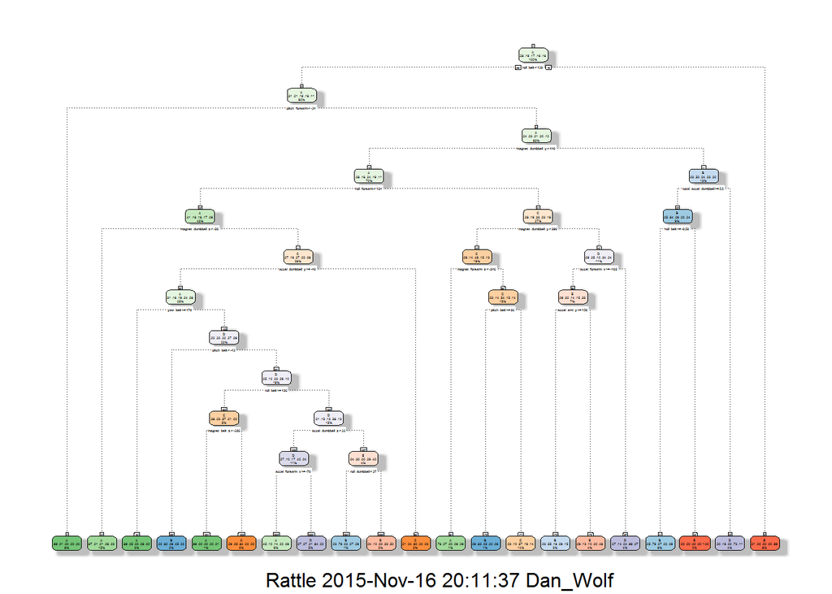

```r
#install.packages("rpart.plot")
mod1 <- rpart(classe~., data=train,method="class")
fancyRpartPlot(mod1)
```

```r
predictMod1<-predict(mod1, holdout,type="class")
confusionMatrix(predictMod1,holdout$classe)
```

```
## Confusion Matrix and Statistics
##
##           Reference
## Prediction    A    B    C    D    E
##          A 2047  334   89  226   62
##          B   57  899  114   51  113
##          C   61  114 1022  190  180
##          D   46  107   97  712   66
##          E   21   64   46  107 1021
##
## Overall Statistics
##
##                Accuracy : 0.7266
##                  95% CI : (0.7166, 0.7365)
##     No Information Rate : 0.2845
##     P-Value [Acc > NIR] : < 2.2e-16
##
##                   Kappa : 0.6512
##  Mcnemar's Test P-Value : < 2.2e-16
##
## Statistics by Class:
##
##                      Class: A Class: B Class: C Class: D Class: E
## Sensitivity            0.9171   0.5922   0.7471  0.55365   0.7080
## Specificity            0.8734   0.9471   0.9159  0.95183   0.9628
## Pos Pred Value         0.7422   0.7285   0.6522  0.69261   0.8110
## Neg Pred Value         0.9636   0.9064   0.9449  0.91581   0.9361
## Prevalence             0.2845   0.1935   0.1744  0.16391   0.1838
## Detection Rate         0.2609   0.1146   0.1303  0.09075   0.1301
## Detection Prevalence   0.3515   0.1573   0.1997  0.13102   0.1605
## Balanced Accuracy      0.8952   0.7696   0.8315  0.75274   0.8354
```

This model misclassifies 27.4% of observations on the holdout. If I applied this model to the 20 test cases I would only get 15 points on the submission! I must do better!

## Step 4b Method 2: Random Forest

Tried other methods - time and space prohibit showing. Random Forest was best.

```r
mod2 <- randomForest(classe~., data=train, importance=TRUE, ntree=500)
mod2
```

```
##
## Call:
##  randomForest(formula = classe ~ ., data = train, importance = TRUE,      ntree = 500)
##                Type of random forest: classification
##                      Number of trees: 500
## No. of variables tried at each split: 7
##
##         OOB estimate of  error rate: 0.65%
## Confusion matrix:
##      A    B    C    D    E  class.error
## A 3347    0    1    0    0 0.0002986858
## B   12 2262    5    0    0 0.0074594120
## C    0   11 2039    4    0 0.0073028238
## D    0    0   31 1897    2 0.0170984456
## E    0    1    3    6 2155 0.0046189376
```

Apply the model to the holdout:

```r
predictMod2<-predict(mod2, holdout,type="class")
confusionMatrix(predictMod2,holdout$classe)
```

```
## Confusion Matrix and Statistics
##
##           Reference
## Prediction    A    B    C    D    E
##          A 2231   17    0    0    0
##          B    0 1498   11    0    0
##          C    0    3 1357   17    1
##          D    0    0    0 1267    5
##          E    1    0    0    2 1436
##
## Overall Statistics
##
##                Accuracy : 0.9927
##                  95% CI : (0.9906, 0.9945)
##     No Information Rate : 0.2845
##     P-Value [Acc > NIR] : < 2.2e-16
##
##                   Kappa : 0.9908
##  Mcnemar's Test P-Value : NA
##
## Statistics by Class:
##
##                      Class: A Class: B Class: C Class: D Class: E
## Sensitivity            0.9996   0.9868   0.9920   0.9852   0.9958
## Specificity            0.9970   0.9983   0.9968   0.9992   0.9995
## Pos Pred Value         0.9924   0.9927   0.9848   0.9961   0.9979
## Neg Pred Value         0.9998   0.9968   0.9983   0.9971   0.9991
## Prevalence             0.2845   0.1935   0.1744   0.1639   0.1838
## Detection Rate         0.2843   0.1909   0.1730   0.1615   0.1830
## Detection Prevalence   0.2865   0.1923   0.1756   0.1621   0.1834
## Balanced Accuracy      0.9983   0.9925   0.9944   0.9922   0.9977
```

## Step 5: Prepare the OOTFXVAL DATA

```r
#OOTFXVAL<-OOTFXVAL[,8:length(colnames(OOTFXVAL))]
#OOTFXVAL<-OOTFXVAL[,!names(OOTFXVAL) %in% dropMiss]
sum(is.na(OOTFXVAL))
```

```
## [1] 2000
```

## Step 6: Predict OOTFXVAL DATA

Make prediction on the 20 observations in the test file and write out to 20 files for later submission

```r
predict20 <- predict(mod2, OOTFXVAL, type = "class")
predict20
```

```
##  1  2  3  4  5  6  7  8  9 10 11 12 13 14 15 16 17 18 19 20
##  B  A  B  A  A  E  D  B  A  A  B  C  B  A  E  E  A  B  B  B
## Levels: A B C D E
```

```r
# convert to character
predict20char<-as.character(paste(predict20[]))
#Function to generate file
pml_write_files = function(x){
  n = length(x)
  for(i in 1:n){
    filename = paste0("problem_id_",i,".txt")
    write.table(x[i],file=filename,quote=FALSE,row.names=FALSE,col.names=FALSE)
  }
}

pml_write_files(predict20char)
```